Biostatistics

**Chapters**

**On this page**

# Regression Analysis

Given two distinct data points, we can always draw a straight line passing through both. However, when we have three non-collinear points, no single straight line can pass through all three.

This raises an interesting question: **If a straight line cannot pass through every data point, can we find one that best represents them?**

This is where regression comes in. Through regression analysis, we attempt to find a line (or a curve) that best captures the overall relationship between two variables, even when the data points do not lie perfectly on a straight line (or a curve).

ℹ️What’s in a name!

In the 1880s, Francis Galton studied the relationship between parents’ and children’s heights. He found that unusually tall parents tended to have children whose heights were less extreme, and similarly for unusually short parents. He called this **regression toward mediocrity** (where *mediocrity* meant the population mean).

Today, **regression** refers to methods for modeling the relationship between variables, even when there is no particular phenomenon of values moving toward the mean.

## 1. Linear regression

When a set of data points does not lie perfectly on a straight line, we may still be able to identify an overall trend. Linear regression is a statistical method used to model this trend by fitting a straight line to the observed data points.

**How do we decide which straight line best represents the data?** There may be many possible lines passing through the general vicinity of the data points. To choose among them, we need a criterion for measuring how well a line fits the data. One widely used approach is the method of *least squares*, which selects the line that minimizes the sum of the squared differences between the observed values and the values predicted by the line.

### 1.1. Line of best fit

To understand the concept of a line of best fit, look at the three graphs in Figure 1, each shows a different line drawn through the same set of data points. By looking at these lines, you might think that the middle one is the line of best fit. However, choosing the line of best fit is not simply about how many data points the line passes through. It is about how closely the line fits the data overall.

To measure how well a line fits the data, we use **residuals**. A residual is the difference between the actual value of a data point and the value predicted by the line. For each data point that does not lie on the line, we can draw a vertical line segment between the point and the line, as shown by the dashed red lines in the graphs. The length of this segment represents the absolute value of the residual.

To determine the line of best fit, we square each residual and add the squared values together. The line that gives the smallest **sum of squared residuals (SSR)** is called the **least-squares line of best fit**. Mathematically,

$\text{SSR} = \sum_{i=1}^{n}(y_i - \hat{y}_i)^2$

Where, $y_i$ is the actual (observed) value of the $i$-th data point, $\hat{y}_i$ is the predicted value from the line of best fit, and $n$ is the total number of data points.

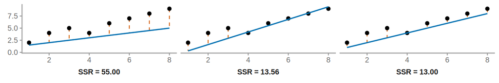

Sum of squared residuals (SSR) for different lines given a set of data points.

**💡What happens when we change the exponent in the SSR formula?**

A [research article](https://www.sciencepublishinggroup.com/article/10.11648/j.ajtas.20241306.12) by Hoffman and Montesinos-Yufa (2024), compares ordinary least squares (p=2) with regression models using different powers, from p=1.2 to p=2.8. It uses simulated data with normal, uniform, exponential and Cauchy error distributions. The authors show that changing p changes the estimated regression coefficients, and that the effect depends on the distribution of the errors.

### 1.2. The Palmer Pengiuns dataset

```r
install.packages("palmerpenguins")
library(palmerpenguins)
```

```r
head(penguins)
```

A tibble: 6 × 8

| species <fct> | island <fct> | bill_length_mm <dbl> | bill_depth_mm <dbl> | flipper_length_mm <int> | body_mass_g <int> | sex <fct> | year <int> |
| --- | --- | --- | --- | --- | --- | --- | --- |
| Adelie | Torgersen | 39.1 | 18.7 | 181 | 3750 | male | 2007 |
| Adelie | Torgersen | 39.5 | 17.4 | 186 | 3800 | female | 2007 |
| Adelie | Torgersen | 40.3 | 18.0 | 195 | 3250 | female | 2007 |
| Adelie | Torgersen | NA | NA | NA | NA | NA | 2007 |
| Adelie | Torgersen | 36.7 | 19.3 | 193 | 3450 | female | 2007 |
| Adelie | Torgersen | 39.3 | 20.6 | 190 | 3650 | male | 2007 |

```r
dim(penguins)
```

1. 344
2. 8

### 1.3. Linear models

Base R provides the `lm()` function, which can be used to fit a linear regression model relating a response variable to one or more predictor variables.

Let's create a model that describes a relationship between a penguin's body mass and its flipper length. In this example, the body mass in the **dependent variable** (or response variable), while flipper is the **independent variable** (or predictor variable).

```r
model <- lm(body_mass_g ~ flipper_length_mm, data = penguins)
```

We can check the model by printing the model, alternately we can use `coef()` function to get the coefficient for the model.

```r
print(model)
```

```
Call:
lm(formula = body_mass_g ~ flipper_length_mm, data = penguins)

Coefficients:
      (Intercept)  flipper_length_mm
         -5780.83              49.69
```

Here, the linear model (or straight line) has an intercept of **-5780.83** and a slope of **49.69**. Based on this we can say that for every 1 mm increase in the penguin's flipper length, the model predicts an average increase of 49.69 grams in body mass. Hence, through this modeling, we have described a *linear* relationship between the two variables.

Note that the large negative intercept has little practical relevance here, since a flipper length of zero is far outside the range of the observed data.

We can write the equation for this model as follows: $$ \text{body mass} = -5780.83 + 49.69\text{(flipper length)}$$

Optionally, we can use the `quatiomatic` package to directly create an equation from the model as shown below.

```r
library(equatiomatic)
library(IRdisplay)

eq1 <- extract_eq(model, use_coefs = TRUE)
eq_latex <- paste0(
  "$$\n",
  as.character(eq1),
  "\n$$"
)
display_markdown(eq_latex)
```

$$ \operatorname{\widehat{body\_mass\_g}} = -5780.83 + 49.69(\operatorname{flipper\_length\_mm}) $$

### 1.4. Ploting a linear model

R provide several convinent ways to plot a linear model. Below are some of the options.

- We can create a scatter plot for the data using the `plot()` function and then add a regression line using `abline()` function which accepts the model as an argument.
- Using ggplot, we can add a layer `geom_abline()` and pass values for the `intercept` and `slope` keyword arguments.
- The `geom_smooth()` function can be used to compute the linear model while plotting.

Figure 2 shows the visualization of the linear regression analysis using the `geom_smooth()` function, using `method = "lm"`.

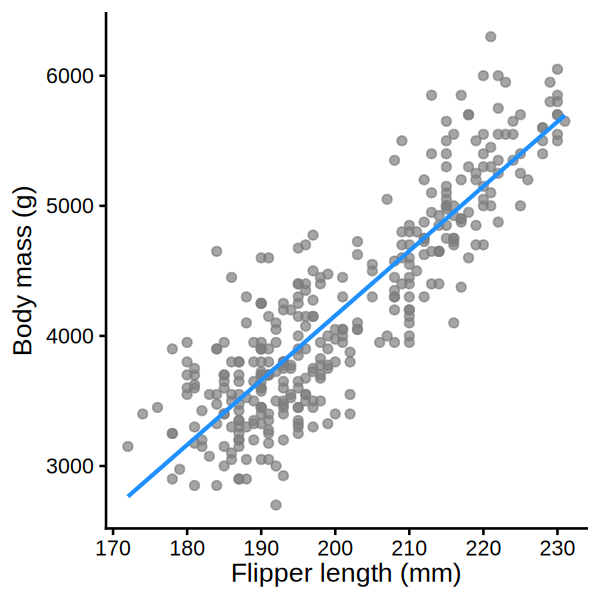

Linear regression showing the line of best fit for predicting body mass from flipper length using the Palmer Penguins dataset.

```r
options(repr.plot.width = 5, repr.plot.height = 5)

penguins |>
  # remove rows with missing values
  drop_na(body_mass_g, flipper_length_mm) |>

ggplot(aes(x = flipper_length_mm, y = body_mass_g)) +
  geom_point(color = "grey50", alpha = 0.7) +
  geom_smooth(
    method = "lm",
    formula = y ~ x, # vertical-axis variable predicted from horizontal-axis variable
    se = FALSE,
    color = "dodgerblue",
    linewidth = 1.2
  ) +
  labs(
    x = "Flipper length (mm)",
    y = "Body mass (g)"
    ) +
  theme_classic(base_size = 16)
```

### 1.5. Predicting values

R's built-in function `predict()` can be used to predict the value of a dependent variable corresponding to the value of an independent variable, based on the linear model. For this we need to create a data frame having value for the independent variable. Note that the column name should match exactly to the variable name in model.

```r
new_penguin <- data.frame(flipper_length_mm = 205)
predict(model, newdata = new_penguin)
```

**1:** 4404.70975517345

Similarly, we can do prediction for multiple pengiuns as well.

```r
new_penguins <- data.frame(flipper_length_mm = c(180, 200, 220))
data.frame(predict(model, newdata = new_penguins))
```

A data.frame: 3 × 1

|  | predict.model..newdata...new_penguins. <dbl> |
| --- | --- |
| 1 | 3162.571 |
| 2 | 4156.282 |
| 3 | 5149.993 |

```r
# Get predictions along with 95% prediction intervals
predict(model, newdata = new_penguins, interval = "prediction")
```

A matrix: 3 × 3 of type dbl

|  | fit | lwr | upr |
| --- | --- | --- | --- |
| 1 | 3162.571 | 2383.398 | 3941.743 |
| 2 | 4156.282 | 3379.612 | 4932.951 |
| 3 | 5149.993 | 4371.240 | 5928.747 |

## 2. Multiple regression

So far, we have built linear models with a single dependent variable and a single independent variable. However, real-world phenomena are typically influenced by *multiple* factors. When building a predictive model, we need to account for all these relevant independent variables—an approach known as **multiple regression**. The underlying concept remains similar to simple linear regression, except that there are distinct terms for each predictor. Mathematically, the general equation for multiple regression is expressed as:

$$y = \beta_0 + \beta_1x_1 + \beta_2x_2 + \dots + \beta_nx_n$$

Let's build a model that describes the relationship between the body mass and two other variables (flipper length and bill length) from the penguin dataset. We can use the same `lm()` function for this as follows.

```r
model <- lm(body_mass_g ~ flipper_length_mm + bill_length_mm, data = penguins)
model
```

```
Call:
lm(formula = body_mass_g ~ flipper_length_mm + bill_length_mm,
    data = penguins)

Coefficients:
      (Intercept)  flipper_length_mm     bill_length_mm
        -5736.897             48.145              6.047
```

Notice now we have two different slope values corresponding to the two independent variables – flipper length and bill length. The equation for this multiple regression model is given below.

$$ \operatorname{\widehat{body\_mass\_g}} = -5736.9 + 48.14(\operatorname{flipper\_length\_mm}) + 6.05(\operatorname{bill\_length\_mm}) $$

Based on this model, we can make the following inferences:

- Holding bill length constant, there is an estimated average increase of 48.14 grams in the body mass for every 1mm increase in flipper length.
- Holding flipper length constant, there is an estimated average increase of 6.05 grams in the body mass for every 1mm increase in bill length.

ℹ️*Ceteris paribus*

*Ceteris paribus* is a Latin phrase meaning "other things being equal" (or in the context of regression, holding all other variables in the model constant). This phrase is commonly used to express the interpretation of regression models, as shown below:

- *Ceteris paribus*, there is an estimated average increase of 48.14 grams in body mass for every 1 mm increase in flipper length.
- *Ceteris paribus*, there is an estimated average increase of 6.05 grams in body mass for every 1 mm increase in bill length.

### 2.1. Visualizing multiple regression

When we have multiple independent variables, the regression model draws a plane instead of a straight line. For up to two independent variables, we can visualize this plane using a 3D plot. However, when we have more than two independent variables, a single 3D visualization is no longer possible. Instead, there are several alternative and effective ways to visualize multiple regression. For instance, the `ggeffects` package can be used to plot each independent variable individually while holding the other variables at a constant value, as shown in Figure 3.

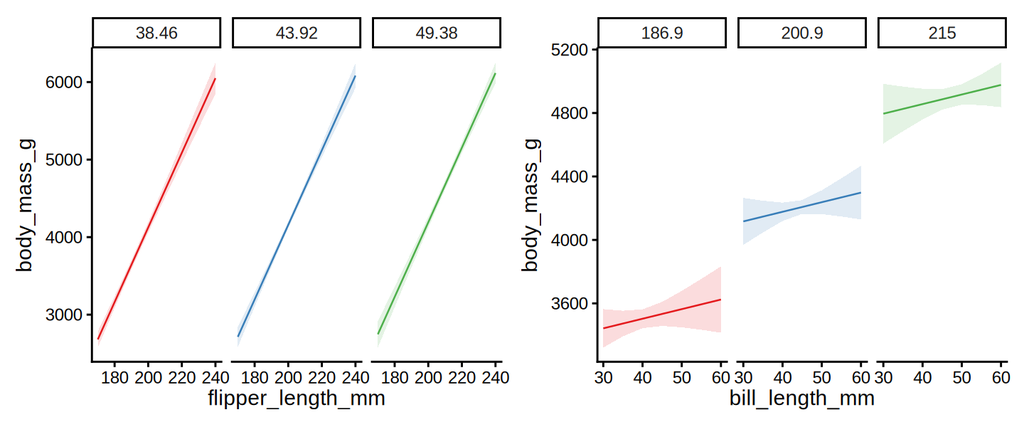

Visualization of the multiple regression model. **Left:** Estimated regression lines for predicting body mass from flipper length, with each line holding bill length constant at a specific value. **Right:** Estimated regression lines for predicting body mass from bill length, with each line holding flipper length constant. In each panel, the first variable in the `terms` argument serves as the primary predictor (X-axis), while the second variable is split into multiple lines.

```r
library(ggeffects)
library(patchwork)

options(repr.plot.width = 12, repr.plot.height = 5)

p1 <- ggpredict(model, terms = c("flipper_length_mm", "bill_length_mm")) |>
  plot(facet = TRUE) +
  theme_classic(base_size = 18) +
  labs(title = NULL)

p2 <- ggpredict(model, terms = c("bill_length_mm","flipper_length_mm")) |>
  plot(facet = TRUE) +
  theme_classic(base_size = 18) +
  labs(title = NULL)
p1+p2
```

### 2.2. Regression using categorical data

When we include categorical data in a regression model, R automatically performs dummy encoding by creating binary indicator variables ($0$ or $1$) for the categories. Rather than building separate models, a single linear model uses these indicators to assign each species a unique intercept while sharing a common slope. By default, R arranges categories in alphabetical order, making the first category the baseline reference. Therefore, in the Penguins dataset, Adelie is considered the baseline when running the regression analysis.

Let's create a model to describe penguin's body mass based on flipper length and species. Table shows how to interpret the three intercept that we get from this model.

```r
model <- lm(body_mass_g ~ flipper_length_mm + species, data = penguins)
model
```

```
Call:
lm(formula = body_mass_g ~ flipper_length_mm + species, data = penguins)

Coefficients:
      (Intercept)  flipper_length_mm   speciesChinstrap      speciesGentoo
         -4031.48              40.71            -206.51             266.81
```

The regression equation for this model will be:

$$ \operatorname{\widehat{body\_mass\_g}} = -4031.48 + 40.71(\operatorname{flipper\_length\_mm}) - 206.51(\operatorname{species}_{\operatorname{Chinstrap}}) + 266.81(\operatorname{species}_{\operatorname{Gentoo}}) $$

Dummy coding breakdown and resulting regression equations for penguin species.

| Species | Chinstrap (Dummy) | Gentoo (Dummy) | Mathematical Equation | Resulting Intercept | Slope |
| --- | --- | --- | --- | --- | --- |
| **Adelie** *(Baseline)* | $0$ | $0$ | $\text{Body Mass} = \beta_0 + \beta_1(\text{Flipper})$ | $\beta_0$ | $\beta_1$ |
| **Chinstrap** | $1$ | $0$ | $\text{Body Mass} = (\beta_0 + \beta_2) + \beta_1(\text{Flipper})$ | $\beta_0 + \beta_2$ | $\beta_1$ |
| **Gentoo** | $0$ | $1$ | $\text{Body Mass} = (\beta_0 + \beta_3) + \beta_1(\text{Flipper})$ | $\beta_0 + \beta_3$ | $\beta_1$ |

The prediction of dependant variable value in case of multiple regression model works similar to the way we did it for linear regression model.

```r
new_penguins <- data.frame(
  flipper_length_mm = c(190, 190, 210),
  species = c("Adelie", "Chinstrap", "Adelie")
)

predict(model, newdata = new_penguins)
```

**1**

3702.54925698967

**2**

3496.03913664995

**3**

4516.65727253528

**Visualization using `ggpredict`**

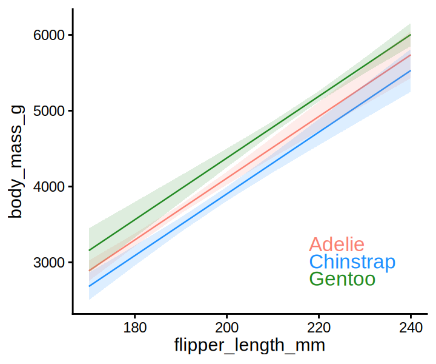

Visualization of the multiple regression model to describe penguin's body mass based on flipper length and species. Note that all the three lines have identical slope while their intercepts are different.

```r
library(ggeffects)
library(ggtext)
options(repr.plot.width = 6, repr.plot.height = 5)

species_colors <- c("Adelie" = "salmon", "Chinstrap" = "dodgerblue", "Gentoo" = "forestgreen")
ggpredict(model, terms = c("flipper_length_mm", "species")) |>
  plot() +
  theme_classic(base_size = 18) +
  labs(title = NULL) +
  scale_color_manual(
    values = species_colors,
    labels = c(
      paste0("<span style='color:", species_colors["Adelie"], "'>Adelie</span>"),
      paste0("<span style='color:", species_colors["Chinstrap"], "'>Chinstrap</span>"),
      paste0("<span style='color:", species_colors["Gentoo"], "'>Gentoo</span>")
    )) +
  scale_fill_manual(
    values = species_colors,
    guide = "none"
  ) +
  guides(
    color = guide_legend(
      override.aes = list(linewidth = 0, linetype = 0)
    )
  ) +
  theme(
    legend.text = element_markdown(size = 20),
    legend.title = element_blank(),
    legend.key = element_rect(fill = NA, color = NA),
    legend.key.width = unit(0, "pt"),
    legend.key.height = unit(0, "pt"),
    legend.position = c(1, 0.05),
    legend.justification = c("right", "bottom")
  )
```

### 2.3. Testing multiple model

Regression analysis is based on several underlying assumptions. Once we have built a multiple regression model, we must test it to ensure that those assumptions are diligently addressed. Frequently performed tests include—but are not limited to—checking the **linearity** of relationships, **homogeneity of variance** (ensuring prediction errors remain uniform across all fitted values), **normality of residuals**, and **multicollinearity** among the predictor variables.

While we can perform these tests using base R functions, the `easystats` ecosystem makes it remarkably easy to run these checks and visualize the results in a unified dashboard. You can install the core meta-package using the command `install.packages("easystats")`.

Table gives a brief description for all the diagnostic plots generated by `check_model()` function. Note that the Collinearity (VIF - Variance Inflation Factor) plot is omitted for simple linear regression since it is based on correlation between the predictor variables.

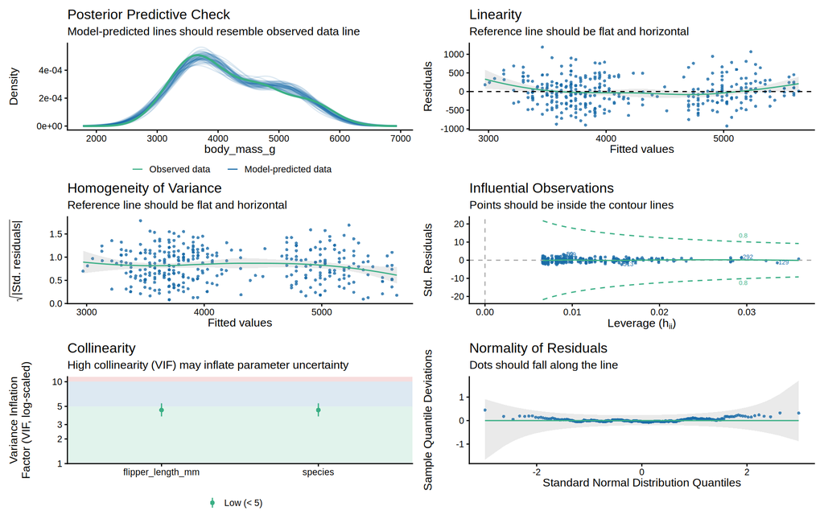

Visualization of various diagnotic analysis of the regression model using the `check_model()` function.

Brief description of the diagnostic plots generated by the `check_model()` function.

| Diagnostic Plot | What It Measures | What to Look For (Ideal) |
| --- | --- | --- |
| **1. Posterior Predictive Check** | Compares actual data distribution to model simulations. | Simulated lines (blue) closely track the observed data (green line). |
| **2. Linearity** | Tests if the relationship between predictors and outcome is truly linear. | The smooth trend line stays close to the dashed reference line. |
| **3. Homogeneity of Variance** | Checks if residual error spread is constant across all predicted values. | An even, random scatter of points distributed around the dashed reference line. |
| **4. Influential Observations** | Flags data points with disproportionate leverage or Cook's distance. | All points stay safely inside or below Cook's distance boundaries. |
| **5. Collinearity (VIF)** | Evaluates if predictors are redundant due to high inter-correlation. | Low Variance Inflation Factor (VIF) values (typically green/safe zone). |
| **6. Normality of Residuals** | Checks if model errors follow a normal distribution. | Data points closely hug the solid green reference line on the Q-Q plot. |

```r
library(ggplot2)
library(performance)
library(see)

model <- lm(body_mass_g ~ flipper_length_mm + species, data = penguins)

options(repr.plot.width = 16, repr.plot.height = 10)

plot(check_model(model), n_columns = 2, theme = theme_classic(base_size = 16))
```

### 2.4. Model performance assessment

With the `check_model()` function, we can generate a collection of plots to perform a visual analysis of standard regression assumptions. Beyond visuals, the performance package provides dedicated functions like `model_performance()` to quantitatively assess overall model quality. To get all the parameters associated with the model, we can call the `model_parameters()` function. In addition, the `compare_performance()` function can be used to perform a comparative analysis of multiple regression models side-by-side.

```r
library(parameters)
model <- lm(body_mass_g ~ flipper_length_mm + species, data = penguins)
model_parameters(model)
```

Regression model estimates calculated using `model_parameters()` function.

| Parameter | Coefficient | SE | CI | CI_low | CI_high | t | df_error | p |
| --- | --- | --- | --- | --- | --- | --- | --- | --- |
| (Intercept) | -4031.4769 | 584.15134 | 0.95 | -5180.50685 | -2882.44693 | -6.901425 | 338 | 2.551453e-11 |
| flipper_length_mm | 40.7054 | 3.07102 | 0.95 | 34.66468 | 46.74612 | 13.254686 | 338 | 1.401600e-32 |
| speciesChinstrap | -206.5101 | 57.73065 | 0.95 | -320.06672 | -92.95352 | -3.577132 | 338 | 3.980986e-04 |
| speciesGentoo | 266.8096 | 95.26374 | 0.95 | 79.42513 | 454.19408 | 2.800747 | 338 | 5.391808e-03 |

```r
library(performance)
model_performance(model)
```

Regression model performance metrics calculated using `model_performance()` function.

| AIC | AICc | BIC | R2 | R2_adjusted | RMSE | Sigma |
| --- | --- | --- | --- | --- | --- | --- |
| 5031.523 | 5031.702 | 5050.697 | 0.7826479 | 0.7807187 | 373.3325 | 375.5351 |

### 2.5. Comparing models

```r
library(tidyverse)
library(palmerpenguins)
library(performance)
library(see)

# Ensure clean data
df <- penguins %>% drop_na()

# 1. Define competing models
model1 <- lm(body_mass_g ~ flipper_length_mm, data = df)
model2 <- lm(body_mass_g ~ flipper_length_mm + species, data = df)
model3 <- lm(body_mass_g ~ flipper_length_mm + species + bill_length_mm, data = df)

# 2. Compare them all at once (and rank them automatically!)
comparison <- compare_performance(model1, model2, model3, rank = TRUE)

# 3. View as a clean table or markdown
comparison
```

A compare_performance: 3 × 10

| Name <chr> | Model <chr> | R2 <dbl> | R2_adjusted <dbl> | RMSE <dbl> | Sigma <dbl> | AIC_wt <dbl> | AICc_wt <dbl> | BIC_wt <dbl> | Performance_Score <dbl> |
| --- | --- | --- | --- | --- | --- | --- | --- | --- | --- |
| model3 | lm | 0.8243043 | 0.8221617 | 337.0077 | 339.5666 | 1.000000e+00 | 1.000000e+00 | 1.000000e+00 | 1.0000000 |
| model2 | lm | 0.7870333 | 0.7850913 | 371.0352 | 373.2839 | 3.335124e-14 | 3.461151e-14 | 2.238926e-13 | 0.2210171 |
| model1 | lm | 0.7620922 | 0.7613734 | 392.1603 | 393.3433 | 2.418503e-21 | 2.652517e-21 | 7.316942e-19 | 0.0000000 |

### 2.6. Visualizing performance across models

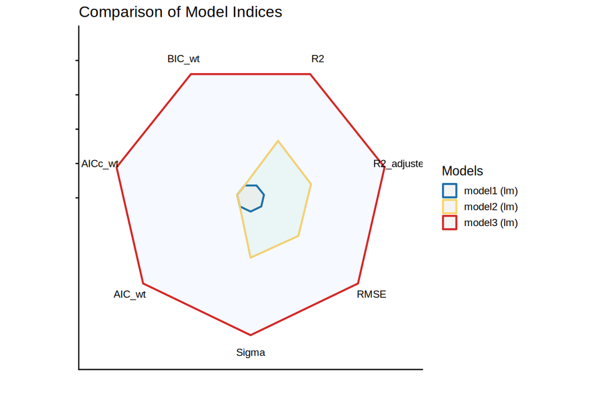

```r
options(repr.plot.width = 9, repr.plot.height = 6)

plot(comparison) + theme_classic(base_size = 14)
```

```r
# Extract the exact coefficients for Model 3
model3 <- lm(body_mass_g ~ flipper_length_mm + species + bill_length_mm, data = df)
coef(model3)
```

**(Intercept)**

-3864.07323411886

**flipper_length_mm**

27.5442861236828

**speciesChinstrap**

-732.416673207492

**speciesGentoo**

113.2541752724

**bill_length_mm**

60.1173245626618

```r
# Extract coefficients from your model
b <- coef(model3)

# Automatically print your equation text using base R
cat(sprintf(
  "Body Mass = %.2f + (%.2f * Flipper) + (%.2f * Bill) + (%.2f * Chinstrap) + (%.2f * Gentoo)\n",
  b["(Intercept)"],
  b["flipper_length_mm"],
  b["bill_length_mm"],
  b["speciesChinstrap"],
  b["speciesGentoo"]
))
```

```
Body Mass = -3864.07 + (27.54 * Flipper) + (60.12 * Bill) + (-732.42 * Chinstrap) + (113.25 * Gentoo)
```

```r
library(equatiomatic)

# Fit Model 3
model3 <- lm(body_mass_g ~ flipper_length_mm + species + bill_length_mm, data = df)

# Generate the equation automatically!
eq <- extract_eq(model3, wrap = TRUE, terms_per_line = 2)
cat(as.character(eq))
```

[output not shown]

$$ \begin{aligned} \operatorname{body\_mass\_g} &= \alpha + \beta_{1}(\operatorname{flipper\_length\_mm})\ + \\ &\quad \beta_{2}(\operatorname{species}_{\operatorname{Chinstrap}}) + \beta_{3}(\operatorname{species}_{\operatorname{Gentoo}})\ + \\ &\quad \beta_{4}(\operatorname{bill\_length\_mm}) + \epsilon \end{aligned} $$

```r
df_gentoo <- penguins %>%
  drop_na() %>%
  mutate(species = relevel(factor(species), ref = "Gentoo"))

# 2. Verify the new order of levels
print(levels(df_gentoo$species)) # Should output: "Gentoo" "Adelie" "Chinstrap"

# 3. Fit the model again using the same formula
model_gentoo <- lm(body_mass_g ~ flipper_length_mm + species + bill_length_mm, data = df_gentoo)

# 4. View the new coefficients
coef(model_gentoo)
```

```
[1] "Gentoo"    "Adelie"    "Chinstrap"
```

**(Intercept)**

-3750.81905884646

**flipper_length_mm**

27.5442861236828

**speciesAdelie**

-113.2541752724

**speciesChinstrap**

-845.670848479892

**bill_length_mm**

60.1173245626618

```r
# 1. Relevel species so Chinstrap is Level 1
df_chinstrap <- penguins %>%
  drop_na() %>%
  mutate(species = relevel(factor(species), ref = "Chinstrap"))

# 2. Verify the new order of levels
print(levels(df_chinstrap$species)) # Should output: "Chinstrap" "Adelie" "Gentoo"

# 3. Fit the model and view coefficients
model_chinstrap <- lm(body_mass_g ~ flipper_length_mm + species + bill_length_mm, data = df_chinstrap)
coef(model_chinstrap)
```

```
[1] "Chinstrap" "Adelie"    "Gentoo"
```

**(Intercept)**

-4596.48990732635

**flipper_length_mm**

27.5442861236828

**speciesAdelie**

732.416673207492

**speciesGentoo**

845.670848479891

**bill_length_mm**

60.1173245626618

```r
library(tidyverse)
library(palmerpenguins)
library(performance)

# 1. Prepare data for predicting sex
adelie_df <- penguins %>%
  filter(species == "Adelie") %>%
  drop_na(sex, bill_length_mm, bill_depth_mm, flipper_length_mm, body_mass_g)

# 2. Define your candidate models based on biological hypotheses
# Model A: Bill dimensions + Body Mass
model_a <- glm(sex ~ bill_length_mm + bill_depth_mm + body_mass_g,
               data = adelie_df, family = binomial)

# Model B: Bill length + Body Mass (simpler)
model_b <- glm(sex ~ bill_length_mm + body_mass_g,
               data = adelie_df, family = binomial)

# Model C: The "Global" model with everything
model_global <- glm(sex ~ bill_length_mm + bill_depth_mm + flipper_length_mm + body_mass_g,
                    data = adelie_df, family = binomial)

# 3. Compare them all at once using easystats
compare_performance(model_a, model_b, model_global, metrics = "AICc")
```

A compare_performance: 3 × 4

| Name <chr> | Model <chr> | AICc <dbl> | AICc_wt <dbl> |
| --- | --- | --- | --- |
| model_a | glm | 62.30747 | 0.708980296 |
| model_b | glm | 73.49996 | 0.002631568 |
| model_global | glm | 64.10651 | 0.288388136 |

```r
library(tidyverse)
library(palmerpenguins)
library(performance)

# 1. Prepare data
adelie_df <- penguins %>%
  filter(species == "Adelie") %>%
  select(sex, bill_length_mm, bill_depth_mm, flipper_length_mm, body_mass_g) %>%
  drop_na() %>%
  mutate(sex = as.factor(sex))

# 2. Fit models
model_a <- glm(sex ~ bill_length_mm + bill_depth_mm + body_mass_g,
               data = adelie_df, family = binomial)
model_b <- glm(sex ~ bill_length_mm + body_mass_g,
               data = adelie_df, family = binomial)
model_global <- glm(sex ~ bill_length_mm + bill_depth_mm + flipper_length_mm + body_mass_g,
                    data = adelie_df, family = binomial)

# 3. Get AICc and weights via easystats performance
comp <- compare_performance(model_a, model_b, model_global, metrics = "AICc")
summary_df <- as.data.frame(comp) %>%
  mutate(Delta_AICc = AICc - min(AICc)) %>%
  select(Name, AICc, Delta_AICc, AICc_wt)

# 4. Robust metric extractor using base R model properties
extract_metrics <- function(mod, data) {
  # McFadden's R2 via deviance ratio (bulletproof for glm binomial)
  r2_mf <- 1 - (mod$deviance / mod$null.deviance)

  # Classification accuracy using a 0.5 probability threshold
  preds <- predict(mod, type = "response")
  pred_class <- ifelse(preds > 0.5, levels(data$sex)[2], levels(data$sex)[1])
  accuracy <- mean(pred_class == data$sex) * 100

  tibble(
    r2_mf = r2_mf,
    percent_correct = accuracy
  )
}

# 5. Bind metrics cleanly by model name
models_list <- list(model_a = model_a, model_b = model_b, model_global = model_global)
extra_metrics_df <- map_dfr(models_list, extract_metrics, data = adelie_df, .id = "Model_Key")

# 6. Merge into final clean summary table
final_table <- summary_df %>%
  mutate(Model_Key = c("model_a", "model_b", "model_global")) %>%
  left_join(extra_metrics_df, by = "Model_Key") %>%
  select(-Model_Key)

print(final_table)
```

```
          Name     AICc Delta_AICc     AICc_wt     r2_mf percent_correct
1      model_a 62.30747   0.000000 0.708980296 0.7330827        91.78082
2      model_b 73.49996  11.192496 0.002631568 0.6673355        89.72603
3 model_global 64.10651   1.799041 0.288388136 0.7347915        93.15068
```